# Qualtrics Assignment #2 – Experimentation

Author

Yushan Huang

Published

September 30, 2026

# 1 Overview

This report documents the modifications completed for Qualtrics Assignment #2 – Experimentation. The project was renamed **Social Media Opinion Leader-Experimental Design**. The work focused on (1) implementing a between-subjects experimental design using Randomizer and Branch functions, (2) improving Q2.2 so that social-media usage can be measured separately for each platform used by a participant, and (3) identifying three additional questionnaire improvements.

The assignment instructions emphasize documenting the full survey flow and showing enough Qualtrics settings and screenshots to make the work gradeable. The report therefore includes screenshots of the relevant Qualtrics programming and preview results.

# 2 Experimental Design: Random Assignment

## 2.1 Research design

The survey contains two advertisement conditions: **social_media_review** and **ads**. Participants should be exposed to only one of these two conditions and then continue to the same dependent-variable questions. This is implemented as a between-subjects design using random assignment.

## 2.2 Randomizer setup

The Randomizer was inserted immediately after the existing participant `id` embedded-data assignment. It was configured to randomly present **1** of the available elements and to **Evenly Present Elements**.

Two embedded-data conditions were created:

- `Ad Type = reviewer`
- `Ad Type = ads`

### 2.2.1 Survey flow: Randomizer

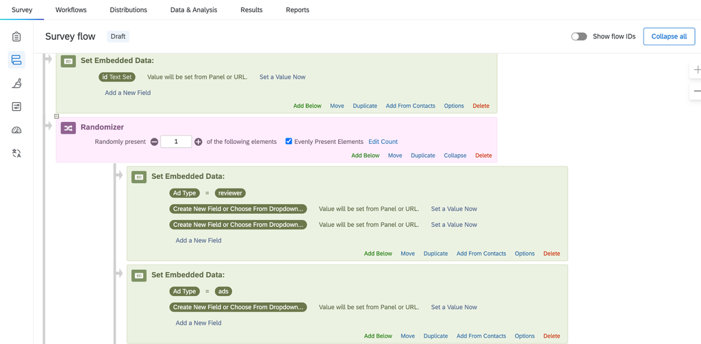

The Randomizer is set to present one condition at a time, which prevents a participant from receiving both advertisement treatments.

## 2.3 Branch setup

Two Branch elements were then used to route participants according to the randomized `Ad Type` value.

The first Branch checks:

> `Ad Type` is equal to `reviewer`

and contains the `social_media_review` block.

The second Branch checks:

> `Ad Type` is equal to `ads`

and contains the `ads` block.

The `DV`, `Purchasing Behavior`, and `Demographics` blocks remain outside the two branches so that participants in either experimental condition continue to the same later questions.

### 2.3.1 Survey flow: Branches

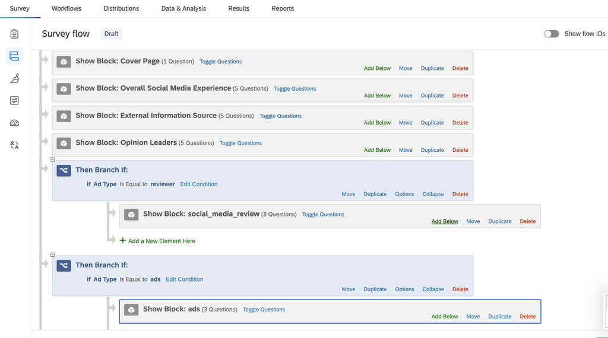

### 2.3.2 Survey flow: downstream blocks

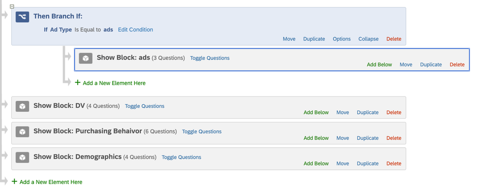

# 3 Improvement of Q2.2: Social Media Usage by Platform

## 3.1 Problem with the original Q2.2

The original Q2.2 asked respondents to report the amount of time they spent on social media platforms as a whole. That format could not identify the usage rate for each individual platform.

## 3.2 Revised Q2.2: Select all platforms used

The revised Q2.2 asks:

> **Which of the following social media platforms do you use? Please select all that apply.**

The response options are:

- Facebook
- Instagram
- Twitter/X
- Snapchat
- Other

The question is configured to **Allow multiple answers**, so respondents can identify all platforms they use rather than only one.

## 3.3 Follow-up matrix with Carry Forward

A second question was added using a Matrix Table format:

> **How much time do you spend on each of the following social media platforms per day?**

The rows use **Carry Forward Statements** from Q2.2 and retain **Selected Choices**. This means that the follow-up matrix displays only the platforms selected by the respondent in Q2.2.

The usage-rate response options are:

- 1 hour or less per day
- 1–2 hours per day
- 3–4 hours per day
- 4–5 hours per day
- 5 or more hours per day

### 3.3.1 Carry Forward configuration

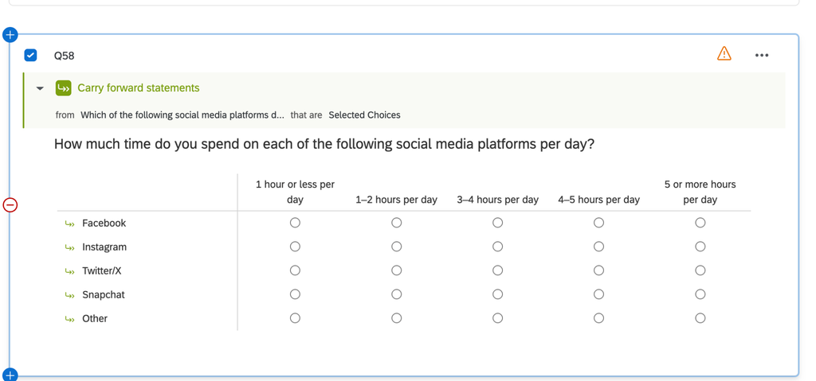

## 3.4 Preview verification

A Preview test was conducted by selecting **Facebook** and **Instagram** in the platform-selection question. The follow-up matrix displayed only Facebook and Instagram, demonstrating that the Carry Forward function is working correctly.

[figure not shown]

# 4 Three Additional Questionnaire Improvements

The following three improvements are intended to improve clarity, response quality, and consistency without changing the underlying research purpose of the questionnaire.

## 4.1 Improvement 1: Clarify Q4.2 wording

### 4.1.1 Original

> Please indicate the extent to which you would rely on the following to get recommendations from to purchase a product?

### 4.1.2 Revised

> **Please indicate the extent to which you would rely on each of the following sources for product purchase recommendations.**

### 4.1.3 Why this is an improvement

The revised wording is shorter and grammatically clearer. It explicitly identifies the items as **sources** and removes the confusing phrase “get recommendations from to purchase a product.” Clearer wording can reduce interpretation differences across respondents.

## 4.2 Improvement 2: Clarify the Q4.2 response scale

### 4.2.1 Original scale

The original scale used labels only for the endpoints, with the middle response options shown only as numbers:

> 1 - A lot | 2 | 3 | 4 | 5 - Not at all

### 4.2.2 Revised scale

Use explicit verbal anchors for every point:

- 1 – A lot
- 2 – Quite a bit
- 3 – Somewhat
- 4 – A little
- 5 – Not at all

### 4.2.3 Why this is an improvement

Labeling every response point provides a clearer interpretation of the scale and makes the meaning of the middle categories easier to understand.

## 4.3 Improvement 3: Clarify Q3.5 wording

### 4.3.1 Original

> How often do you purchase a product or service that a social media opinion leader posted about? (Instagram, Facebook, Twitter etc…)

### 4.3.2 Revised

> **How often do you purchase a product or service after seeing it recommended or promoted by a social media opinion leader?**

### 4.3.3 Why this is an improvement

The revised wording makes the intended behavior more specific. “Posted about” can refer to many kinds of mentions, while “recommended or promoted” more directly describes the social-media influence being measured.

# 5 Final Check

# 6 Appendix